# Segunda Entrega P2

Estadística y Probabilidad 1

24 de Junio del 2022

# Contenidos

1. Introducción
   - Relevancia del tema escogido
   - Planificación
2. Datos
   - Proceso de recolección de datos
   - Población, muestra y muestreo
   - Variables
   - Limpieza de base de datos
3. Análisis descriptivo
4. Análisis probbilístico
5. Variable aleatoria

# 1 Introducción

**1.1 Relevancia:**

Muchos estudiantes universitarios consumen bebidas energéticas debido a diversas razones tales como la necesidad de mantenerse despierto en ciertas horas, tener más energía o lo atribuyen a la acción de hacer ejercicio, entre otros. Es de conocimiento universal el hecho de que estas bebidas generan a largo y corto plazo diferentes consecuencias a la salud. Por ello, es importante estudiar cómo se plasman dichas consecuencias en la salud. Con este estudio podremos llegar a conclusiones estadísticas respecto a la preferencia de la marca de bebida energética, frecuencia de cantidad, etc. Lo cual es suficiente para deducir si el consumidor tendrá problemas de salud, cambios de rutinas o cualquier efecto secundario que pueda generar el consumo excesivo de dichas bebidas.

**1.2 Planificación:**

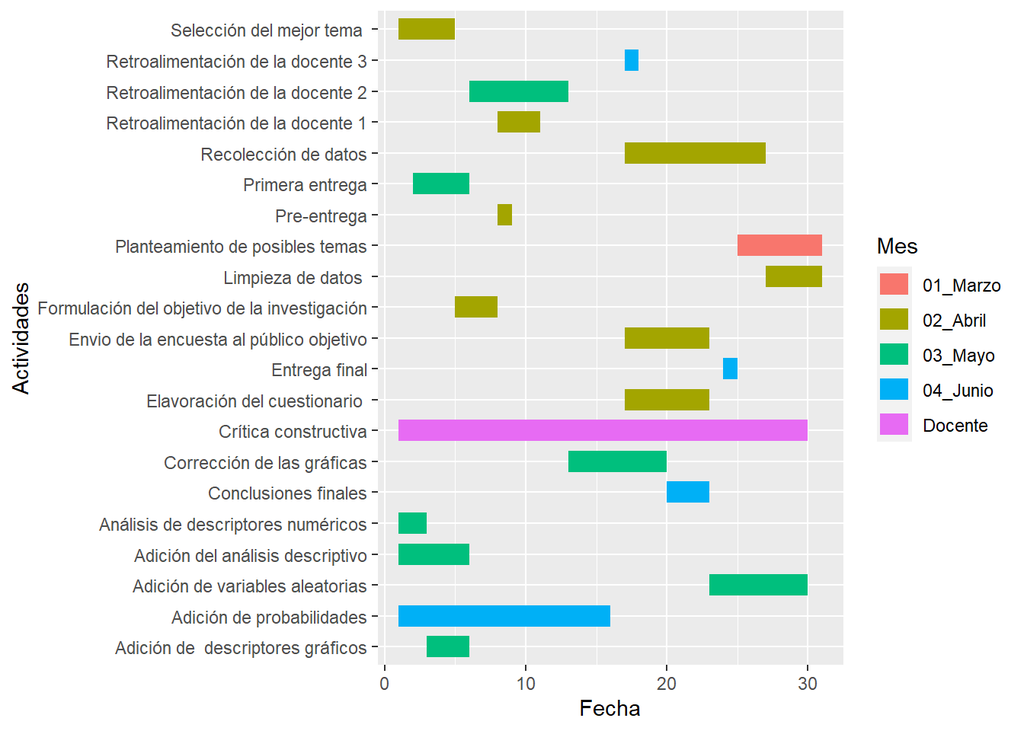

```r
library(ggplot2)
data_1 <- data.frame(Actividades = c('Planteamiento de posibles temas',
                                     'Selección del mejor tema ',
                                     'Formulación del objetivo de la investigación',
                                     'Pre-entrega',
                                     'Retroalimentación de la docente 1',
                                     'Elavoración del cuestionario ',
                                     'Envio de la encuesta al público objetivo',
                                     'Recolección de datos',
                                     'Limpieza de datos ',
                                     'Análisis de descriptores numéricos',
                                     'Adición de  descriptores gráficos',
                                     'Adición del análisis descriptivo',
                                     'Primera entrega',
                                     'Retroalimentación de la docente 2',
                                     'Corrección de las gráficas',
                                     'Adición de variables aleatorias',
                                     'Adición de probabilidades',
                                     'Retroalimentación de la docente 3',
                                     'Conclusiones finales',
                                     'Entrega final','Crítica constructiva'),


Fecha = c(25, 1,5,8,  8, 17, 23, 17, 27, 1, 3, 1, 2, 6 , 13, 23,  1, 17, 20, 24,1),
end = c(31, 5,8,9, 11, 23, 17, 27, 31, 3, 6, 6, 6, 13, 20, 30, 16, 18, 23, 25,30),
Mes = c('01_Marzo',
        '02_Abril', '02_Abril','02_Abril','02_Abril','02_Abril','02_Abril','02_Abril','02_Abril',
        '03_Mayo','03_Mayo','03_Mayo','03_Mayo','03_Mayo','03_Mayo','03_Mayo',
        '04_Junio','04_Junio','04_Junio','04_Junio','Docente'))
ggplot(data_1, aes(x=Fecha, xend=end,y=Actividades, yend=Actividades, color=Mes)) + geom_segment(size=5)
```

# 2 Datos